# Guilherme Gomes

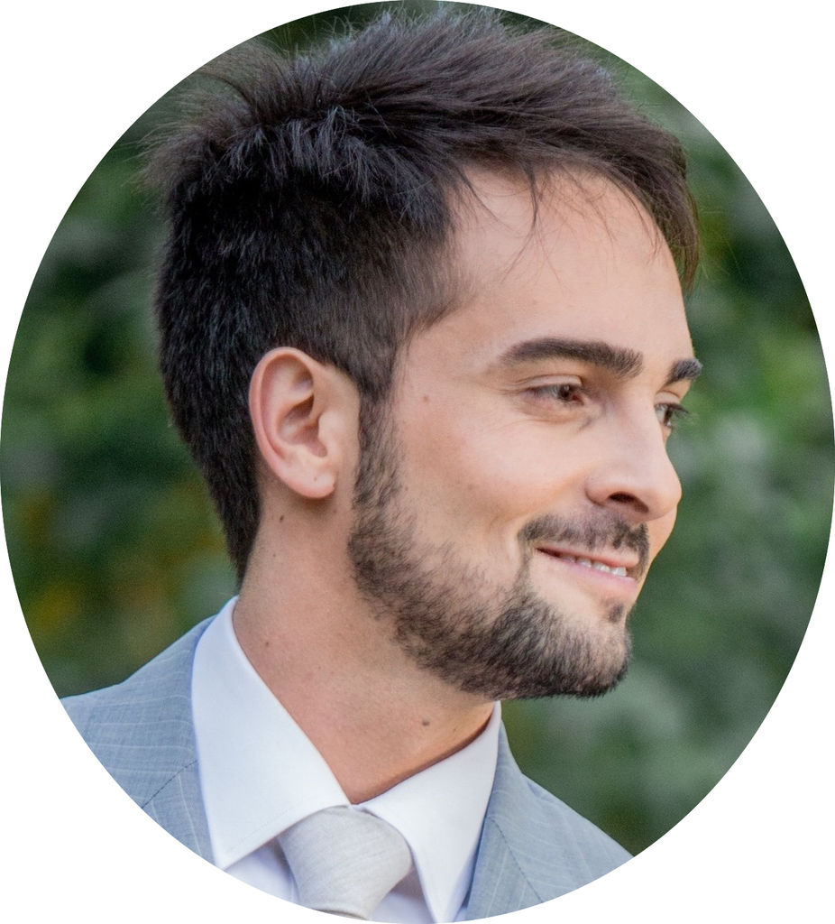

Statistician | Data Scientist | gomesg [at] purdue

|

## Currently

I am postdoc in the Department of Computer Science at Purdue University with research, industry and teaching experience. My currently research focus is on *statistical network analysis*, where I am advised by [Jennifer Neville](https://www.cs.purdue.edu/homes/neville/) and [Vinayak Rao](https://varao.github.io/). Broadly, my interests are in the field of highly complex statistical inference models, such as bayesian statistics and deep learning.

## Education

`2013 - 2019` **Purdue University, IN**

- [Ph.D. in Statistics](https://kurtmaia.github.io/thesis.pdf)
- Advisors: Dr. Jennifer Neville and Dr. Vinayak Rao

`2008 - 2012` **University of Brasilia, Brazil**

- B.S. in Statistics

## Experience

`2017 - present` **Purdue University, IN**

- Research Assistant
- – Research focus on Statistical Network Analysis
- – Investigate problems related to population of Networks (e.g. brain networks, social networks, word co-occurrences, protein-protein networks, gene co-expression networks, financial networks, etc)
- – Three ongoing projects:
- - 1. Extend hypothesis testing for weighted networks.
- - 2. Devise a joint clustering model for heterogeneous networks.
- - 3. Formulate a model for dynamic networks.

`2015 - 2017` **Cook Research, IN**

- Statistician Intern
- – Improved and created routines in R/SAS to facilitate exploratory and inferential reports. Those reports are essential to be done fast and precise due to FDA audit reasons.
- – Collaborated with the clinical research team providing statistical tools for all phases of the experiment analysis:
- - – Aided plan and design experiments of projects in inception stage (e.g. sample size calculations, formulate problem definition, literature review, understand the limitations, etc).
- - – Analyzed data for on going and follow-up stage project using survival models, linear/non linear regressions, etc

`2012 - 2013` **SAS Institute, Brazil**

- SAS Instructor Provided SAS trainings to enterprises such as: consulting (Deloitte, Accenture), banks (Bank ofBrazil, Caixa Economica, Santander, Itaú), telecommunications (Anatel, Sky, NET) and other governmental institutions. Those trainings were focused on SAS programming (basic and advance) and statistical modeling.

`2010 - 2012` **Central Bank of Brazil, Brazil**

- Researcher Intern
- – Collaborated with a team of economists in different types of research projects
- – Led the implementation and analysis of statistical (econometric) models
- – Three main research projects (results were published in Econometric journals):
- - 1. Measured bank efficiency in Brazil using Stochastic frontier analysis
- - 2. Modeled market power of Brazilian banks using local regression method
- - 3. Designed an algorithm to find optimal smooth parameter in local regression
- – Prepared series of SAS macros and SATA mata to facilitate analysis and report generation.

## Teaching experience

`2014 - 2015` **Purdue University, IN**

- Teacher Assistant
- Course: Elementary statistical methods course for undergraduate students.

`2012` **University of Brasilia, Brazil**

- Teacher Assistant
- Course: basic econometrics.

## Research interests

### Specific

Bayesian non-parametric, Dirichlet processes, spectral clustering, random effect models, graph convolution networks, graph embedding, model-based hypothesis testing.

### General

Machine learning, statistical network analysis, big data, deep learning, bayesian analysis, multivariate analysis, time series, distributed computing.

## Publications

`2018` *Gomes, G.*; [Rao, Vinayak](https://varao.github.io/index.html); [Neville, Jennifer](https://www.cs.purdue.edu/homes/neville/). [Multi-level hypothesis testing for populations of heterogeneous networks. International Conference on Data Mining (ICDM 2018)](https://arxiv.org/abs/1809.02512)

`2015` [Tabak, B. M. ; *Gomes, G. M.*; Júnior, M. S. The impact of market power at bank level in risk-taking: The Brazilian case. International Review of Financial Analysis, Volume 40.](http://sbfin.org.br/artigos-aceitos-15sbfin/econometria/5092.pdf)

`2015` Schul, M. W. ; Schloerke, B.; *Gomes, G. M.* The refluxing anterior accessory saphenous vein demonstrates similar clinical severity when compared to the refluxing great saphenous vein. Phlebology.

`2012` Tabak, B.M.; Sollaci, A.B.; *Gomes, G. M.*; Cajueiro, D.O. Forecasting the yield curve for the Euro region. Economics Letters, v. 117, p.513-516.

## Preprint

`2019` *Gomes, G.*; [Rao, Vinayak](https://varao.github.io/index.html); [Neville, Jennifer](https://www.cs.purdue.edu/homes/neville/). [Community detection over a heterogeneous population of non-aligned networks.](https://arxiv.org/pdf/1904.05332.pdf)

## Computational skills

R, Python, SAS, MySQL, Matlab, spark, STATA

## Languages

### Fluent

Portuguese, English

### Intermediate

French, Spanish